# Prédiction du niveau de virulence et du pouvoir colonisateur de souches de Salmonelles à partir de données spectroscopiques infra-rouges

Adélina Joanita Anato, Stéphanie Bougeard, Emmanuelle Houard, Martine Denis

2022-09-14

# 1 Objectifs

Objectifs :

- Prédiction du niveau de virulence de souches de Salmonelles à partir de nombre d’ondes,
- Prédiction du niveau de pouvoir colonisateur de Salmonelles à partir de nombre d’ondes,
- En tenant compte de la variabilité issue de différentes expériences (oct-20, avr-21, jan-22) et différents réplicats (5 réplicats au maximum par souche de salmonelle et par expérience).

Plus précisément :

- 3 niveaux de virulence à prédire,
- 4 niveaux de pouvoir colonisateur,
- à partir de 501 nombre d’ondes issues d’analyses spectroscopiques infra-rouges,
- 15 souches disponibles,
- 5 réplicats (au maximum) par souche et par expérience, soit au plus 15 réplications pour une souche donnée.

# 2 Packages et fonctions requis

```r
library(ggplot2)
library(gridExtra)
library(agricolae)
library(caret)
library(reshape2)
library(knitr)
library(corrplot)
library(ClustVarLV)
library(mixOmics)
library(FactoMineR)
library(factoextra)
library(randomForest)
library(randomForestExplainer)
library(tidyverse)
library(tibble)
library(readxl)
library(labeling)
library(kknn)
library(xlsx)

S4_to_dataframe <- function(s4obj){
  nms <- slotNames(s4obj)
  lst <- lapply(nms, function(nm) slot(s4obj, nm))
  as.data.frame(setNames(lst, nms))
}
```

# 3 Import et préparation des données

- 222 observations (= souches),
- 2 variables à expliquer (virulence, pouvoir colonisateur),
- 3 facteurs relatifs au plan d’expérience (date, souche, réplicat),
- 501 nombres d’ondes.

Etude de la structure du plan d’expérience :

```r
table(Caco2.Adh_Inv, Date)
```

```
##              Date
## Caco2.Adh_Inv 2020-10-01 2021-04-01 2022-01-01
##            HV         10          9         10
##            IV         43         45         45
##            LV         20         20         20
```

```r
table(IpecJ2.Adh_Inv, Date)
```

```
##               Date
## IpecJ2.Adh_Inv 2020-10-01 2021-04-01 2022-01-01
##            HC          24         25         25
##            HIC         14         15         15
##            LC          15         15         15
##            LIC         20         19         20
```

```r
table(Souches, Date)
```

```
##             Date
## Souches      2020-10-01 2021-04-01 2022-01-01
##   07 CR 073           5          5          5
##   07 CR 095           4          5          5
##   07 CR 179           5          5          5
##   07 CR 223           5          5          5
##   07 CR 553           5          5          5
##   08 MD 138           5          5          5
##   08 MD 869           5          5          5
##   S12 AK 050          5          5          5
##   S12 AK 059          4          5          5
##   S12 AK 070          5          4          5
##   S12 AK 086          5          5          5
##   S12 AK 100          5          5          5
##   S12 AK 107          5          5          5
##   S12 AK 118          5          5          5
##   S14 CH 063          5          5          5
```

```r
table(Souches, Caco2.Adh_Inv)
```

```
##             Caco2.Adh_Inv
## Souches      HV IV LV
##   07 CR 073   0 15  0
##   07 CR 095   0 14  0
##   07 CR 179   0 15  0
##   07 CR 223   0  0 15
##   07 CR 553   0  0 15
##   08 MD 138   0 15  0
##   08 MD 869   0  0 15
##   S12 AK 050 15  0  0
##   S12 AK 059  0 14  0
##   S12 AK 070 14  0  0
##   S12 AK 086  0 15  0
##   S12 AK 100  0  0 15
##   S12 AK 107  0 15  0
##   S12 AK 118  0 15  0
##   S14 CH 063  0 15  0
```

```r
table(Souches, IpecJ2.Adh_Inv)
```

```
##             IpecJ2.Adh_Inv
## Souches      HC HIC LC LIC
##   07 CR 073   0   0  0  15
##   07 CR 095   0  14  0   0
##   07 CR 179  15   0  0   0
##   07 CR 223   0  15  0   0
##   07 CR 553  15   0  0   0
##   08 MD 138   0   0 15   0
##   08 MD 869   0   0 15   0
##   S12 AK 050  0  15  0   0
##   S12 AK 059 14   0  0   0
##   S12 AK 070  0   0  0  14
##   S12 AK 086  0   0  0  15
##   S12 AK 100  0   0 15   0
##   S12 AK 107  0   0  0  15
##   S12 AK 118 15   0  0   0
##   S14 CH 063 15   0  0   0
```

```r
table(IpecJ2.Adh_Inv)    # répartition des souches selon le niveau de virulence
```

```
## IpecJ2.Adh_Inv
##  HC HIC  LC LIC
##  74  44  45  59
```

```r
table(Caco2.Adh_Inv)     # répartition des souches selon le niveau de pouvoir colonisateur
```

```
## Caco2.Adh_Inv
##  HV  IV  LV
##  29 133  60
```

**Bilan** : Toutes les souches ont été analysées à toutes les dates de même que les niveaux de virulence et de pouvoir colonisateur (pas de biais pour la suite des analyses statistiques).

# 4 Illustration des données

## 4.1 Spectres selon la virulence

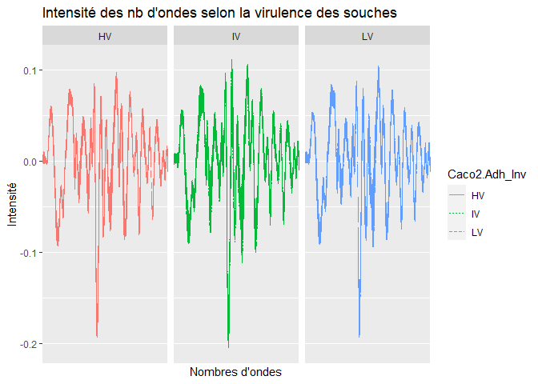

```r
Data.col <- melt(Data, id = c('Date', 'Caco2.Adh_Inv','IpecJ2.Adh_Inv', 'Souches', 'Réplicats'))
ggplot(Data.col, aes(x = variable, y = value)) + geom_line(aes(color = Caco2.Adh_Inv, linetype = Caco2.Adh_Inv)) + xlab("Nombres d'ondes") + ylab("Intensité") + scale_x_discrete(labels = NULL, breaks = NULL) + facet_wrap(~ Caco2.Adh_Inv)+ ggtitle ("Intensité des nb d'ondes selon la virulence des souches")
```

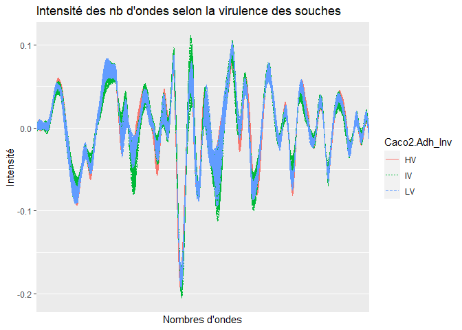

```r
ggplot(Data.col, aes(x = variable, y = value)) + geom_line(aes(color = Caco2.Adh_Inv, linetype = Caco2.Adh_Inv)) + xlab("Nombres d'ondes") + ylab("Intensité") + scale_x_discrete(labels = NULL, breaks = NULL)+ ggtitle ("Intensité des nb d'ondes selon la virulence des souches")
```

## 4.2 Spectre selon le pouvoir colonisateur

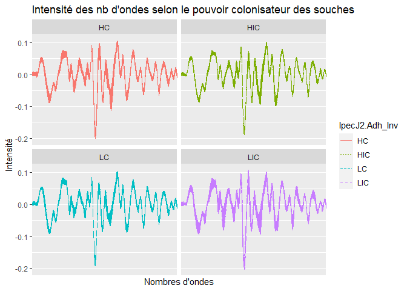

```r
ggplot(Data.col, aes(x = variable, y = value)) + geom_line(aes(color = IpecJ2.Adh_Inv, linetype = IpecJ2.Adh_Inv)) + xlab("Nombres d'ondes") + ylab("Intensité") + scale_x_discrete(labels = NULL, breaks = NULL) + facet_wrap(~ IpecJ2.Adh_Inv)+ ggtitle ("Intensité des nb d'ondes selon le pouvoir colonisateur des souches")
```

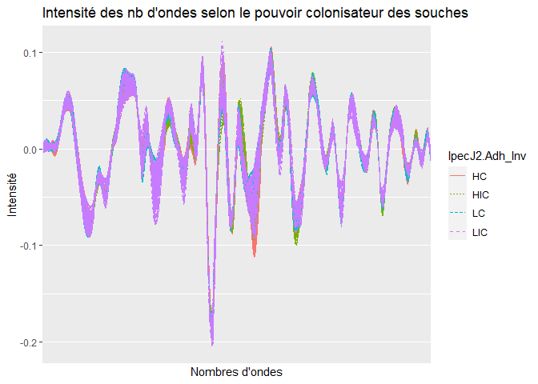

```r
ggplot(Data.col, aes(x = variable, y = value)) + geom_line(aes(color = IpecJ2.Adh_Inv, linetype = IpecJ2.Adh_Inv)) + xlab("Nombres d'ondes") + ylab("Intensité") + scale_x_discrete(labels = NULL, breaks = NULL)+ ggtitle ("Intensité des nb d'ondes selon le pouvoir colonisateur des souches")
```

# 5 Analyse univariée (par nombre d’ondes)

Identifier les nombres d’ondes qui ont une influence sur le niveau de virulence et le pouvoir colonisateur des souches.

- **Objectif** : Identifier les nombres d’ondes d’intérêt.
- **Méthode** : Les nombres d’ondes n’ayant pas tous des distributions normales, des tests non-paramétriques de Kruskall-Wallis sont appliqués.

## 5.1 Identification des nombres d’onde liés avec le niveau de virulence

Test de Kruskall-Wallis :

```r
res.kruskal           <- data.frame(matrix(NA, ncol = 1, nrow = (ncol(Data) - 5)))
rownames(res.kruskal) <- colnames(Data[, 6 : ncol(Data)])
colnames(res.kruskal) <- c('Virulence.KW.pvalue')
for (i in 6 : ncol(Data)){
  res.kruskal[i-5, ] <- kruskal.test(Data[, i] ~ Caco2.Adh_Inv, data = Data)$p.value
}
# rownames(res.kruskal)[which(res.kruskal > 0.05)]
```

**Bilan** : 102 nombres d’ondes ne différencient pas les niveaux de virulence de façon significative.

Comparaisons ajustées des niveaux de virulence deux à deux (tests de Mann&Whitney ajustés) :

```r
res.comp <- list()
for (i in 6 : ncol(Data)){
  group           <- kruskal(Data[, i], Data$Caco2.Adh_Inv, p.adj = "holm")$groups
  group.tri       <- group[order(rownames(group)), 2]
  res.comp[[i-5]] <- group.tri
}
res.comp.tot           <- do.call("rbind", res.comp)
colnames(res.comp.tot) <- sort(levels(Data$Caco2.Adh_Inv))
res.univar             <- cbind.data.frame(res.kruskal, res.comp.tot)
colnames(res.univar)   <- c('Virulence.KW.pvalue  ',    'HV  ', 'IV  ', 'LV')
kable(head(res.univar, 10))
```

|  | Virulence.KW.pvalue | HV | IV | LV |
| --- | --- | --- | --- | --- |
| X1300 | 0.0780286 | a | a | a |
| X1299 | 0.0893226 | a | a | a |
| X1298 | 0.1362240 | a | a | a |
| X1297 | 0.2071799 | a | a | a |
| X1296 | 0.3224763 | a | a | a |
| X1295 | 0.3499489 | a | a | a |
| X1294 | 0.3545161 | a | a | a |
| X1293 | 0.3128850 | a | a | a |
| X1292 | 0.1147074 | a | a | a |
| X1291 | 0.0381292 | b | ab | a |

## 5.2 Identification des nombres d’onde liés avec le pouvoir colonisateur

```r
res.kruskal2           <- data.frame(matrix(NA, ncol = 1, nrow = (ncol(Data)-5)))
rownames(res.kruskal2) <- colnames(Data[, 6 : ncol(Data)])
colnames(res.kruskal2) <- c('Colonisation.KW.pvalue')
for (i in 6 : ncol(Data)){
  res.kruskal2[i-5, ] <- kruskal.test(Data[, i] ~ IpecJ2.Adh_Inv, data = Data)$p.value
}
# rownames(res.kruskal2)[which(res.kruskal2 > 0.05)]
```

**Bilan** : 35 nombres d’ondes ne différencient pas les niveaux de pouvoir colonisateur de façon significative.

Comparaisons ajustées des niveaux de virulence deux à deux (tests de Mann&Whitney ajustés) :

```r
res.comp2 <- list()
for (i in 6 : ncol(Data)){
  group2           <- kruskal(Data[, i], Data$IpecJ2.Adh_Inv, p.adj = "holm")$groups
  group2.tri       <- group2[order(rownames(group2)), 2]
  res.comp2[[i-5]] <- group2.tri
}
res.comp2.tot           <- do.call("rbind", res.comp2)
colnames(res.comp2.tot) <- sort(levels(Data$IpecJ2.Adh_Inv))
res.univar2             <- cbind.data.frame(res.kruskal2, res.comp2.tot)
colnames(res.univar2)   <- c('Colonisation.KW.pvalue  ',    'HC  ','HIC  ', 'LC  ', 'LIC')
kable(head(res.univar2, 10))
```

|  | Colonisation.KW.pvalue | HC | HIC | LC | LIC |
| --- | --- | --- | --- | --- | --- |
| X1300 | 0.0433137 | b | ab | a | ab |
| X1299 | 0.0496284 | a | a | a | a |
| X1298 | 0.0668016 | a | a | a | a |
| X1297 | 0.0641881 | ab | b | a | ab |
| X1296 | 0.0517799 | ab | b | a | ab |
| X1295 | 0.0212466 | ab | b | a | ab |
| X1294 | 0.0048477 | ab | b | a | a |
| X1293 | 0.0001638 | a | b | a | a |
| X1292 | 0.0000011 | a | b | a | a |
| X1291 | 0.0000000 | b | c | a | a |

## 5.3 Synthèse des résultats univariés

```r
res.univar3 <- cbind(res.univar, res.univar2)
kable(head(res.univar3))
```

|  | Virulence.KW.pvalue | HV | IV | LV | Colonisation.KW.pvalue | HC | HIC | LC | LIC |
| --- | --- | --- | --- | --- | --- | --- | --- | --- | --- |
| X1300 | 0.0780286 | a | a | a | 0.0433137 | b | ab | a | ab |
| X1299 | 0.0893226 | a | a | a | 0.0496284 | a | a | a | a |
| X1298 | 0.1362240 | a | a | a | 0.0668016 | a | a | a | a |
| X1297 | 0.2071799 | a | a | a | 0.0641881 | ab | b | a | ab |
| X1296 | 0.3224763 | a | a | a | 0.0517799 | ab | b | a | ab |
| X1295 | 0.3499489 | a | a | a | 0.0212466 | ab | b | a | ab |

# 6 Analyse exploratoire multivariée : illustration des liens entre nombres d’ondes

## 6.1 Corrélation deux à deux

- Une image de la matrice de corrélation est proposée (en ligne et en colonne, les 501 nombres d’ondes et en couleur, l’illustration de leur corrélation).
- Il apparaît des groupes de nombres d’ondes très corrélés entre eux (blocs de couleur bleu foncé) et très anti-corrélés entre eux (blocs de couleur rouge).

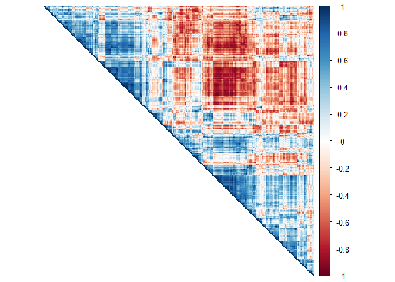

```r
corrplot(cor(Data[, -c(1:5)], method = "spearman"), method = "color", type = "upper", order = 'hclust', tl.pos='n')
```

## 6.2 Classification de variables

- Afin de déterminer le nombre optimal de bloc de nombres d’ondes corrélées (= donnant la même information), une classification des 501 nombres d’ondes est appliquée.
- La variation du critère indique qu’une classification en 7 classes est optimale. Cela signifie que 7 directions principales permettent de résumer l’information contenue par les 501 nombres d’ondes.

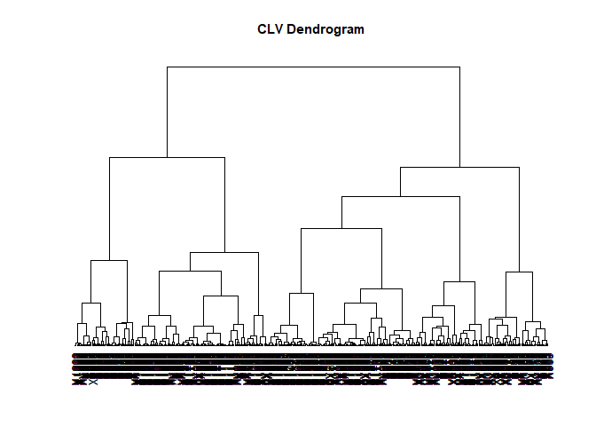

```r
res.clv <- CLV(Data[, -c(1:5)], method = "directional", sX = TRUE, nmax = 30, maxiter = 50)
plot(res.clv, type = "dendrogram")
```

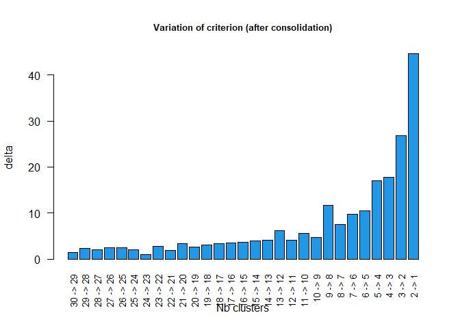

```r
plot(res.clv, type = "delta")
```

```r
table(get_partition(res.clv, K = 7))
```

```
##
##   1   2   3   4   5   6   7
##  60 127  70  58  91  27  68
```

```r
# plot_var(res.clv, K = 6, label = F, v_symbol = T, beside = T)
```

Etude des sept classes :

```r
res.cluster <- as.matrix(get_partition(res.clv, K = 7))
t(res.cluster[1:20, ])
```

```
##      X1300 X1299 X1298 X1297 X1296 X1295 X1294 X1293 X1292 X1291 X1290 X1289
## [1,]     2     2     2     2     2     2     2     2     2     2     2     2
##      X1288 X1287 X1286 X1285 X1284 X1283 X1282 X1281
## [1,]     2     2     2     2     2     2     2     2
```

Globalement, les nombres d’ondes se suivent (à quelques exceptions).

**Bilan** : Les 501 nombres d’ondes peuvent se résumer en 7 directions principales. Nous allons étudier par la suite quelles sont ces directions et si elles permettent de différencier les pouvoirs colonisateur et/ou les niveaux de virulence.

# 7 Analyse exploratoire multivariée : analyse discriminante PLS

## 7.1 Objectifs

- Visualiser s’il est possible de différencier les modalités des deux facteurs (i.e., virulence et pouvoir colonisateur),
- Visualiser quels nombres d’ondes sont impliquées dans ces différenciations,
- Prendre en compte et/ou visualiser l’effet dû aux expériences, souches et réplicats.

## 7.2 Méthode sélectionnée

Spécificité des données :

- **Y** = Une variable à expliquer nominale (= pouvoir colonisateur ou niveau de virulence),
- **X** = 501 variables explicatives quantitatives liées entre elles (NB : plus de variables que d’observations ; 501 versus 222),
- Une structure des observations possiblement liée aux expériences (souches et réplicats).

Méthode exploratoire multivariée : Du fait des objectifs et des spécificités des données, la méthode **PLS discriminante sparse et multigroupe** est appliquée. En effet, cette méthode permet de :

- Expliquer une variable (–> PLS) qualitative (–> discriminante),
- A partir de très nombreuses variables quantitatives (–> sparse) potentiellement corrélées (–> PLS),
- Avec une structure sous-jacente des observations (–> multi-groupe)
- NB : Les nombres d’ondes sont considérés comme des variables quantitatives (analyse exploratoire sans tests associés).

Afin que tous les nombres d’ondes aient le même poids dans l’analyse, ceux-ci sont centrés (même moyenne = 0) et réduits (même écart-type = 1).

## 7.3 Résultats selon le niveau de virulence

### 7.3.1 Optimisation préalable des paramètres de la méthode

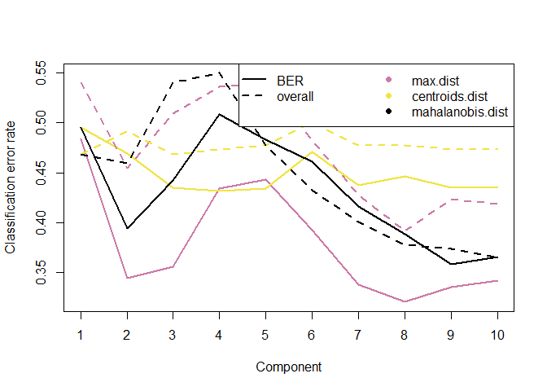

```r
test.nbcomp  <- mint.splsda(X = Data[, -c(1:5)], Y = Data$Caco2.Adh_Inv, study = Data$Date, ncomp = 10, scale = TRUE)
test.nbcomp2 <- perf(test.nbcomp, validation = "Mfold", folds = 5, progressBar = FALSE, nrepeat = 20)
plot(test.nbcomp2, col = color.mixo(5:7), legend.position = "horizontal")
```

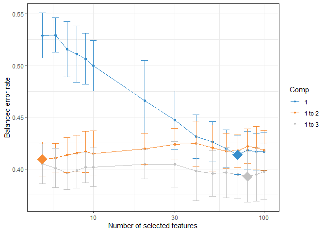

```r
tune.splsda <- tune.splsda(X = Data[, -c(1:5)], Y = Data$Caco2.Adh_Inv, ncomp = c(3:10), validation = 'Mfold', folds = 3, dist = 'centroids.dist', progressBar = FALSE, measure = "BER", test.keepX = c(5:10,  seq(20, 100, 10)), nrepeat = 10)
plot(tune.splsda)
```

```r
ncomp <- tune.splsda$choice.ncomp$ncomp
(select.keepX <- tune.splsda$choice.keepX[1:ncomp])
```

```
## comp1
##    70
```

### 7.3.2 Application de la méthode

- Les deux premières composantes expliquent 95% de l’inertie du tableau Y (différencient bien selon le niveau de virulence).
- Les deux premières composantes expliquent 53% de l’inertie du tableau X.

```r
res.mint.splsda <- mint.splsda(X = Data[, -c(1:5)], Y = Data$Caco2.Adh_Inv, study = Data$Date, keepX = select.keepX, ncomp = 2, scale = TRUE)
res.mint.splsda$prop_expl_var$Y$`all data`
```

```
##     comp1     comp2
## 0.5013780 0.4534664
```

```r
res.mint.splsda$prop_expl_var$X$`all data`
```

```
##     comp1     comp2
## 0.2522944 0.2784967
```

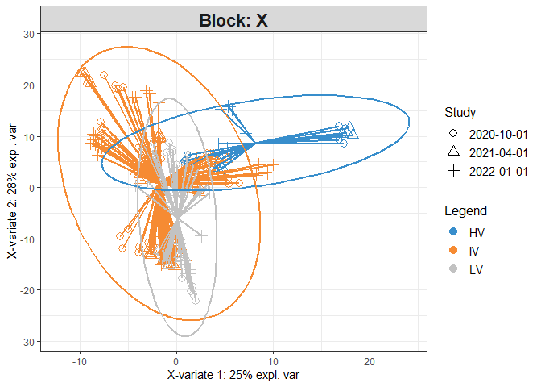

```r
plotIndiv(res.mint.splsda, comp = c(1,2), ind.names = FALSE, group = Data$Caco2.Adh_Inv, legend = TRUE, ellipse = TRUE, star = TRUE)
```

Il semble possible de différencier les niveaux de virulence, mais pour certaines souches plus facilement que pour d’autres.

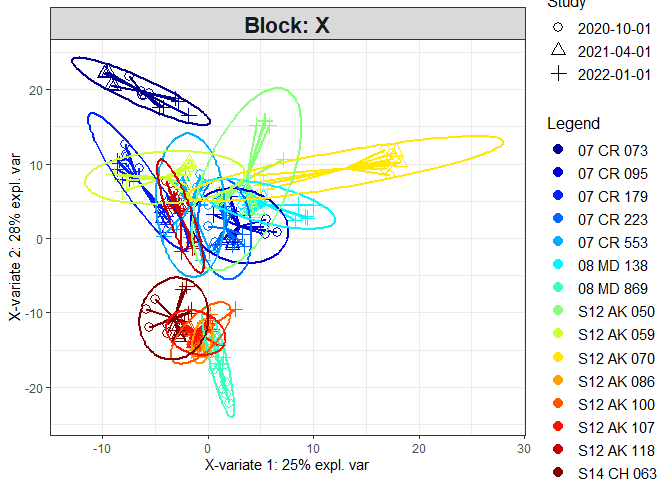

```r
plotIndiv(res.mint.splsda, comp = c(1,2), ind.names = FALSE, group = Data$Souches, legend = TRUE, ellipse = TRUE, star = TRUE)
```

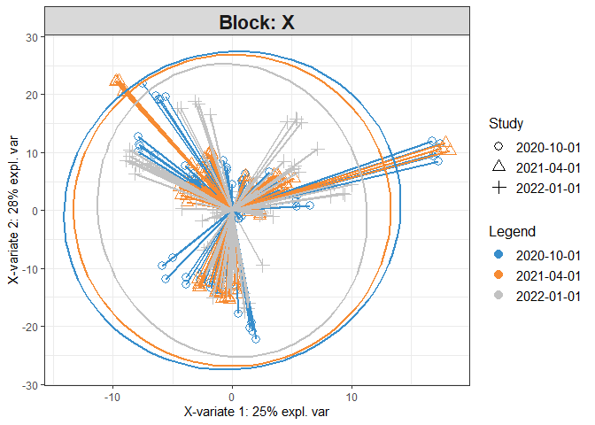

```r
plotIndiv(res.mint.splsda, comp = c(1,2), ind.names = FALSE, group = as.factor(Data$Date), legend = TRUE, ellipse = TRUE, star = TRUE)
```

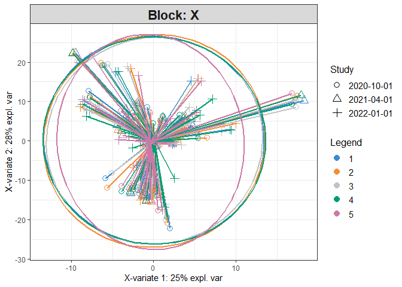

```r
plotIndiv(res.mint.splsda, comp = c(1,2), ind.names = FALSE, group = Data$Réplicats, legend = TRUE, ellipse = TRUE, star = TRUE)
```

- Les souches se différencient bien (cependant, la souche S12-AK-070 est très variable).
- Les expériences sont comparables (cependant, l’expérience 2022-01-01 est moins variable que les autres).
- Les réplicats sont comparables (cependant, le réplicat 5 est moins variable que les autres).

## 7.4 Résultats selon le pouvoir colonisateur

### 7.4.1 Optimisation préalable des paramètres de la méthode

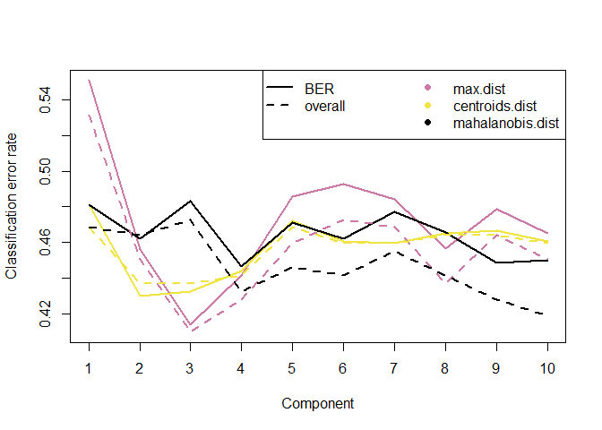

```r
test.nbcomp  <- mint.splsda(X = Data[, -c(1:5)], Y = Data$IpecJ2.Adh_Inv, study = Data$Date, ncomp = 10, scale = TRUE)
test.nbcomp2 <- perf(test.nbcomp, validation = "Mfold", folds = 5, progressBar = FALSE, nrepeat = 20)
plot(test.nbcomp2, col = color.mixo(5:7), legend.position = "horizontal")
```

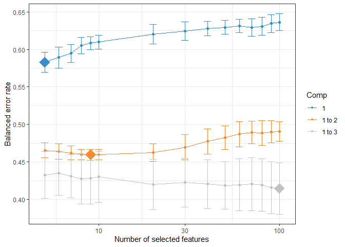

```r
tune.splsda <- tune.splsda(X = Data[, -c(1:5)], Y = Data$IpecJ2.Adh_Inv, ncomp = c(3:10), validation = 'Mfold', folds = 3, dist = 'max.dist', progressBar = FALSE, measure = "BER", test.keepX = c(5:10, seq(20, 100, 10)), nrepeat = 10)
plot(tune.splsda)
```

```r
ncomp <- tune.splsda$choice.ncomp$ncomp
(select.keepX <- tune.splsda$choice.keepX[1:ncomp])
```

```
## comp1 comp2 comp3
##     5     9   100
```

### 7.4.2 Application de la méthode

```r
res.mint.splsda <- mint.splsda(X = Data[, -c(1:5)], Y = Data$IpecJ2.Adh_Inv, study = Data$Date, keepX = select.keepX, ncomp = ncomp, scale = TRUE)
res.mint.splsda$prop_expl_var$Y$`all data`
```

```
##     comp1     comp2     comp3
## 0.3519567 0.3216898 0.3239329
```

```r
res.mint.splsda$prop_expl_var$X$`all data`
```

```
##     comp1     comp2     comp3
## 0.2521235 0.1559181 0.1759697
```

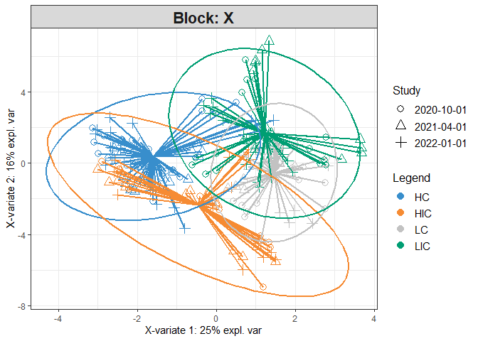

```r
plotIndiv(res.mint.splsda, comp = c(1,2), ind.names = FALSE, group = Data$IpecJ2.Adh_Inv, legend = TRUE, ellipse = TRUE, star = TRUE)
```

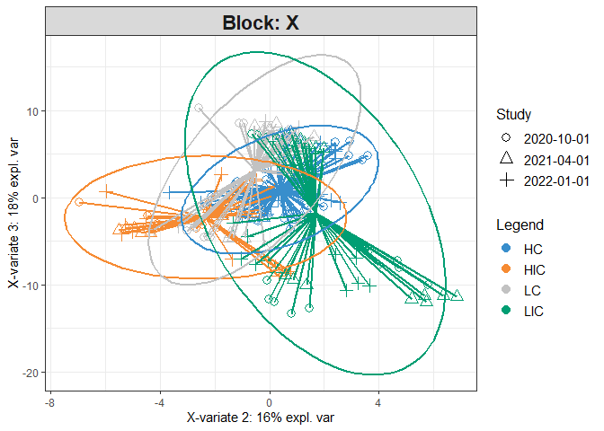

```r
plotIndiv(res.mint.splsda, comp = c(2,3), ind.names = FALSE, group = Data$IpecJ2.Adh_Inv, legend = TRUE, ellipse = TRUE, star = TRUE)
```

Il semble possible de différencier les niveaux de pouvoir colonisateur, mais pour certains plus facilement que pour d’autres.

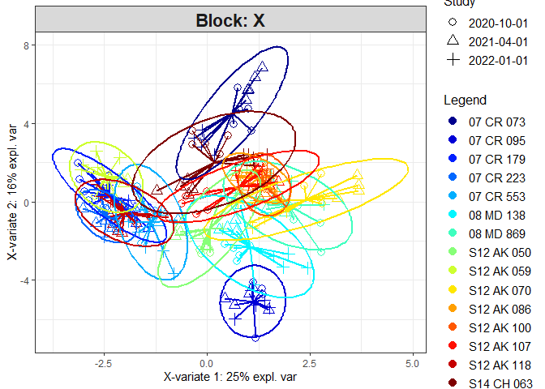

```r
plotIndiv(res.mint.splsda, comp = c(1,2), ind.names = FALSE, group = Data$Souches, legend = TRUE, ellipse = TRUE, star = TRUE)
```

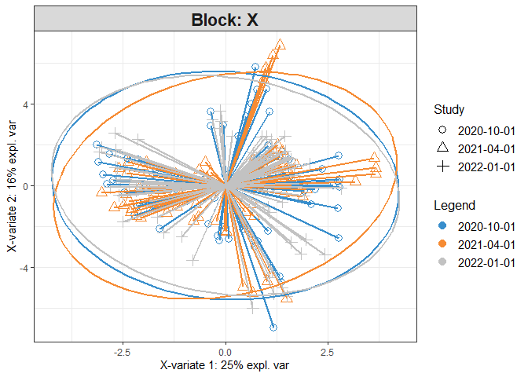

```r
plotIndiv(res.mint.splsda, comp = c(1,2), ind.names = FALSE, group = as.factor(Data$Date), legend = TRUE, ellipse = TRUE, star = TRUE)
```

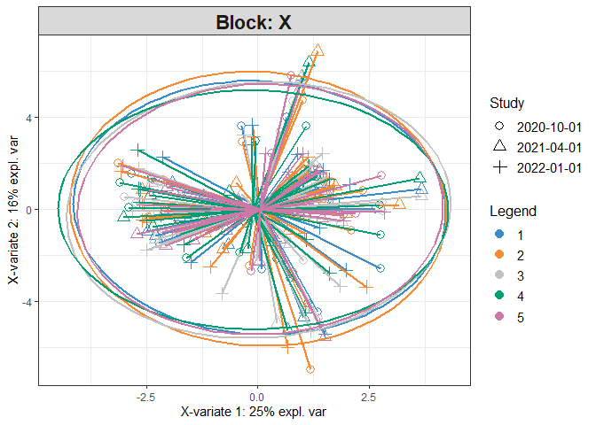

```r
plotIndiv(res.mint.splsda, comp = c(1,2), ind.names = FALSE, group = Data$Réplicats, legend = TRUE, ellipse = TRUE, star = TRUE)
```

- Les souches se différencient bien (cependant, les souches S12-AK-070 ou S12-AK-118 sont très variables).
- Les expériences sont comparables
- Les réplicats sont comparables.

# 8 Analyse prédictive : modèles multivariés

- **Objectif** : Prédiction du niveau de virulence et du pouvoir colonisateur à partir des nombres d’ondes,
- **Méthode** : Apprentissage automatique (application de différents modèles de discrimination).

## 8.1 Modèles de prédiction

Un algorithme de machine learning évaluant 15 modèles multinomiaux possibles est appliqué 50 fois (contrainte : ces modèles doivent être robustes aux variables explicatives très corrélées entre elles). Les modèles sélectionnés appartiennent à différentes catégories statistiques :

- Modèles linéaires généralisés régularisés (glmnet = sparse et ridge)
- Modèles bayésiens : classifieur bayésien naïf (naive_bayes)
- Modèles issus de l’analyse factorielle : analyse discriminante pénalisée (pda), analyse discriminante régularisée (rda), analyse discriminante locale (loclda), kernel PLS (kernelpls)
- Modèles issus des arbres de classification : forêts aléatoires (rf, ranger), bagged CART (treebag), C5.0
- Modèles de discrimination non-paramétrique : K plus proches voisins (kknn),
- Support vector machine (svmLinear, ORFsvm)
- Modèles issus de réseaux de neurones (nnet, mlpML)

### 8.1.1 Modèle pour prédire le niveau de virulence

```r
nbsim <- 50
meth  <- c('glmnet', 'naive_bayes', 'pda', 'rda', 'loclda', 'kernelpls', 'rf', 'ranger', 'treebag', 'C5.0', 'kknn', 'svmLinear', 'ORFsvm', 'nnet', 'mlpML')

res.perf.test            <- array(NA , dim = c(length(meth), 4, nbsim))
colnames(res.perf.test) <- c('%BC.Global', '%BC.HV', '%BC.IV', '%BC.LV')
rownames(res.perf.test) <- meth


for (s in 1 : nbsim){

  print(paste("Simulation.", s))

  # Création des jeux de données d’apprentissage et de test
  trainIndex <- createDataPartition(Data$Caco2.Adh_Inv, p = 0.70, list = FALSE)
  Data.train <- Data[trainIndex, ]    # 70% des observations
  Data.test  <- Data[-trainIndex, ]   # 30% des observations

  # Modèle sur les données d'apprentissage avec optimisation des paramètres par 10-fold CV (non répété)
  set.seed(12345)
  control   <- trainControl(method = "cv", number = 10, p = .9, summaryFunction = multiClassSummary)
  mod.train <- lapply(1:length(meth), function(m) train(Caco2.Adh_Inv ~ ., data = Data.train[, -c(1, 2, 4, 5)], preProcess = c("center", "scale"), method = meth[m], trControl = control, ouput = F))
  on.exit(stopCluster)

  # Prédiction
  pred.test  <- lapply(1:length(meth), function(m) predict(mod.train[[m]], Data.test, preProcess = c("center", "scale")))

  # Performance des modèles
  perf.test  <- lapply(1:length(meth), function(m) confusionMatrix(reference = Data.test$Caco2.Adh_Inv, data = pred.test[[m]]))
  res.perf.test[, 1 , s] <- sapply(1:length(meth), function(m) perf.test[[m]]$overall[1])
  res.perf.test[, 2 , s] <- sapply(1:length(meth), function(m) perf.test[[m]]$byClass['Class: HV', 1])
  res.perf.test[, 3 , s] <- sapply(1:length(meth), function(m) perf.test[[m]]$byClass['Class: IV', 1])
  res.perf.test[, 4 , s] <- sapply(1:length(meth), function(m) perf.test[[m]]$byClass['Class: LV', 1])
  saveRDS(res.perf.test, 'Res.perf.test.virul.rds')
}
```

Les performances (qualité de modélisation et qualité de prédiction moyennées sur les simulations) sont données.

```r
res.perf.test      <- readRDS('Res.perf.test.virul.rds')
res.perf.test.moy0  <- round(apply(res.perf.test, c(1,2), mean, na.rm = T), 3) * 100
res.perf.test.moy <- cbind.data.frame(res.perf.test.moy0, rowMeans(res.perf.test.moy0))
colnames(res.perf.test.moy)[5] <- 'Average'
kable(res.perf.test.moy, format = "html", table.attr = "style='width:30%;'")
```

|  | %BC.Global | %BC.HV | %BC.IV | %BC.LV | Average |
| --- | --- | --- | --- | --- | --- |
| glmnet | 78.9 | 67.5 | 84.7 | 71.2 | 75.575 |
| naive_bayes | 66.6 | 93.0 | 52.7 | 85.2 | 74.375 |
| pda | 72.6 | 80.0 | 72.8 | 68.8 | 73.550 |
| rda | 75.5 | 71.5 | 77.2 | 73.8 | 74.500 |
| loclda | 42.4 | 55.5 | 37.1 | 47.9 | 45.725 |
| kernelpls | 62.4 | 29.5 | 91.3 | 14.6 | 49.450 |
| rf | 87.4 | 76.7 | 98.1 | 69.1 | 82.825 |
| ranger | 90.5 | 84.8 | 98.9 | 75.0 | 87.300 |
| treebag | 79.4 | 70.8 | 90.3 | 59.6 | 75.025 |
| C5.0 | 85.4 | 87.3 | 90.3 | 74.1 | 84.275 |
| kknn | 95.8 | 98.5 | 98.5 | 88.6 | 95.350 |
| svmLinear | 83.1 | 84.8 | 84.1 | 80.2 | 83.050 |
| ORFsvm | 65.3 | 82.8 | 91.8 | 0.0 | 59.975 |
| nnet | 66.2 | 41.2 | 67.6 | 74.3 | 62.325 |
| mlpML | 84.5 | 76.7 | 88.8 | 78.4 | 82.100 |

Application de l’ACP pour la synthèse des performances prédictives.

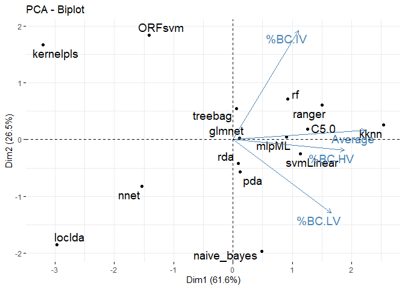

```r
res.pca.pred  <- PCA(res.perf.test.moy[, -1], graph = F)
p1            <- fviz_pca_var(res.pca.pred, repel = T, labelsize = 5)
p2            <- fviz_pca_ind(res.pca.pred, repel = T, labelsize = 5)
fviz_pca_biplot(res.pca.pred, repel = T, labelsize = 5)
```

Le modèle qui prédit au mieux les niveaux de virulence est la classification des plus proches voisins (‘kknn’) avec les performances suivantes :

### 8.1.2 Modèle pour prédire le pouvoir colonisateur

```r
nbsim <- 50
meth  <- c('glmnet', 'naive_bayes', 'pda', 'rda', 'loclda', 'kernelpls', 'rf', 'ranger', 'treebag', 'C5.0', 'kknn', 'svmLinear', 'ORFsvm', 'nnet', 'mlpML')

res.perf.test            <- array(NA , dim = c(length(meth), 5, nbsim))
colnames(res.perf.test) <- c('%BC.Global', '%BC.HC', '%BC.HIC', '%BC.LC', '%BC.LIC')
rownames(res.perf.test) <- meth

for (s in 1 : nbsim){

  print(paste("Simulation.", s))

  # Création des jeux de données d’apprentissage et de test
  trainIndex <- createDataPartition(Data$IpecJ2.Adh_Inv, p = 0.70, list = FALSE)
  Data.train <- Data[trainIndex, ]    # 70% des observations
  Data.test  <- Data[-trainIndex, ]   # 30% des observations


  # Modèle sur les données d'apprentissage avec optimisation des paramètres par 10-fold CV (non répété)
  set.seed(12345)
  control   <- trainControl(method = "cv", number = 10, p = .9, summaryFunction = multiClassSummary)
  mod.train <- lapply(1:length(meth), function(m) train(IpecJ2.Adh_Inv ~ ., data = Data.train[, -c(1, 2, 3, 5)], preProcess = c("center", "scale"), method = meth[m], trControl = control, ouput = F))
  on.exit(stopCluster)

  # Prédiction
  pred.test  <- lapply(1:length(meth), function(m) predict(mod.train[[m]], Data.test, preProcess = c("center", "scale")))

  # Performance des modèles
  perf.test  <- lapply(1:length(meth), function(m) confusionMatrix(reference = Data.test$IpecJ2.Adh_Inv, data = pred.test[[m]]))
  res.perf.test[, 1 , s] <- sapply(1:length(meth), function(m) perf.test[[m]]$overall[1])
  res.perf.test[, 2 , s] <- sapply(1:length(meth), function(m) perf.test[[m]]$byClass['Class: HC', 1])
  res.perf.test[, 3 , s] <- sapply(1:length(meth), function(m) perf.test[[m]]$byClass['Class: HIC', 1])
  res.perf.test[, 4 , s] <- sapply(1:length(meth), function(m) perf.test[[m]]$byClass['Class: LC', 1])
  res.perf.test[, 5 , s] <- sapply(1:length(meth), function(m) perf.test[[m]]$byClass['Class: LIC', 1])
  saveRDS(res.perf.test, 'Res.perf.test.coloni.rds')
}
```

Les performances (qualité de modélisation et qualité de prédiction moyennées sur les simulations) sont données.

```r
res.perf.test       <- readRDS('Res.perf.test.coloni.rds')
res.perf.test.moy0  <- round(apply(res.perf.test, c(1,2), mean, na.rm = T), 3) * 100
res.perf.test.moy   <- cbind.data.frame(res.perf.test.moy0, rowMeans(res.perf.test.moy0))
colnames(res.perf.test.moy)[6] <- 'Average'
kable(res.perf.test.moy, format = "html", table.attr = "style='width:30%;'")
```

|  | %BC.Global | %BC.HC | %BC.HIC | %BC.LC | %BC.LIC | Average |
| --- | --- | --- | --- | --- | --- | --- |
| glmnet | 77.9 | 90.4 | 74.5 | 63.5 | 75.3 | 76.32 |
| naive_bayes | 74.3 | 83.0 | 96.6 | 75.7 | 44.8 | 74.88 |
| pda | 66.1 | 76.5 | 61.8 | 57.2 | 62.5 | 64.82 |
| rda | 72.6 | 88.8 | 74.5 | 67.8 | 53.6 | 71.46 |
| loclda | 38.4 | 41.9 | 41.2 | 27.1 | 40.2 | 37.76 |
| kernelpls | 65.4 | 87.4 | 56.8 | 33.2 | 68.4 | 62.24 |
| rf | 91.4 | 97.7 | 92.6 | 76.8 | 93.5 | 90.40 |
| ranger | 92.9 | 97.5 | 95.1 | 79.1 | 96.0 | 92.12 |
| treebag | 84.0 | 92.0 | 86.8 | 68.6 | 83.3 | 82.94 |
| C5.0 | 87.4 | 94.3 | 90.2 | 75.8 | 85.3 | 86.60 |
| kknn | 95.7 | 97.9 | 96.9 | 86.8 | 98.7 | 95.20 |
| svmLinear | 87.6 | 97.1 | 95.7 | 74.3 | 79.4 | 86.82 |
| ORFsvm | 49.0 | 99.7 | 76.0 | 0.0 | 0.0 | 44.94 |
| nnet | 52.9 | 86.8 | 8.9 | 33.1 | 57.9 | 47.92 |
| mlpML | 83.0 | 92.8 | 87.2 | 70.5 | 76.8 | 82.06 |

Application de l’ACP pour la synthèse des performances prédictives.

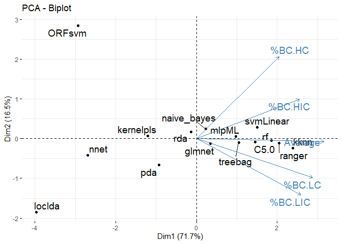

```r
res.pca.pred  <- PCA(res.perf.test.moy[, -1], graph = F)
p1            <- fviz_pca_var(res.pca.pred, repel = T, labelsize = 5)
p2            <- fviz_pca_ind(res.pca.pred, repel = T, labelsize = 5)
fviz_pca_biplot(res.pca.pred, repel = T, labelsize = 5)
```

Le modèle qui prédit au mieux le pouvoir colonisateur est à nouveau la classification des plus proches voisins (‘kknn’) avec les performances suivantes :

## 8.2 Interprétation des modèles optimaux de prédiction

Les deux modèles optimaux (i.e., pour prédire la virulence ou le pouvoir colonisateur) sont appliqués à toutes les souches.

### 8.2.1 Modèle pour les niveaux de virulence

```r
control       <- trainControl(method = "cv", number = 50, p = .8, summaryFunction = multiClassSummary)
mod.virul <- train(Caco2.Adh_Inv ~ ., data = Data[, -c(1, 2, 4, 5)], preProcess = c("center", "scale"), method = 'kknn', trControl = control, ouput = F)
Varimp.virul  <- cbind.data.frame(varImp(mod.virul)$importance$HV, varImp(mod.virul)$importance$IV, varImp(mod.virul)$importance$LV)
Varimp.virul$average   <- as.vector(apply(Varimp.virul, 1, mean))
colnames(Varimp.virul) <- c('HV', 'IV', 'LV', 'Imp.Virul')
rownames(Varimp.virul) <- colnames(Data[, -c(1:5)])
kable(head(Varimp.virul))
```

|  | HV | IV | LV | Imp.Virul |
| --- | --- | --- | --- | --- |
| X1300 | 22.84382 | 17.025956 | 22.84382 | 20.90453 |
| X1299 | 20.86247 | 16.873477 | 20.86247 | 19.53281 |
| X1298 | 20.27972 | 14.687944 | 20.27972 | 18.41579 |
| X1297 | 19.46387 | 12.095799 | 19.46387 | 17.00785 |
| X1296 | 16.20047 | 9.706960 | 16.20047 | 14.03596 |
| X1295 | 13.86946 | 9.427415 | 13.86946 | 12.38878 |

### 8.2.2 Modèle pour le pouvoir colonisateur

```r
mod.coloni <- train(IpecJ2.Adh_Inv ~ ., data = Data[, -c(1, 2, 3, 5)], preProcess = c("center", "scale"), method = 'kknn', trControl = control, ouput = F)
Varimp.coloni <- cbind.data.frame(varImp(mod.coloni)$importance$HC, varImp(mod.coloni)$importance$HIC, varImp(mod.coloni)$importance$LC, varImp(mod.coloni)$importance$LIC)
Varimp.coloni$average   <- as.vector(apply(Varimp.coloni, 1, mean))
colnames(Varimp.coloni) <- c('HC', 'HIC', 'LC', 'LIC', 'Imp.Coloni')
rownames(Varimp.coloni) <- colnames(Data[, -c(1:5)])
kable(head(Varimp.coloni))
```

|  | HC | HIC | LC | LIC | Imp.Coloni |
| --- | --- | --- | --- | --- | --- |
| X1300 | 29.33354 | 7.403332 | 29.79723 | 29.33354 | 23.96691 |
| X1299 | 26.36592 | 2.970764 | 33.02059 | 26.36592 | 22.18080 |
| X1298 | 22.59457 | 6.313409 | 33.74844 | 22.59457 | 21.31275 |
| X1297 | 17.71036 | 14.027536 | 35.20415 | 17.71036 | 21.16310 |
| X1296 | 18.89629 | 18.896288 | 35.41211 | 15.11370 | 22.07959 |
| X1295 | 23.57535 | 23.575348 | 37.80363 | 14.99005 | 24.98609 |

# 9 Synthèse des résultats

## 9.1 Pour les niveaux de virulence

```r
res.final.virul0 <- as.data.frame(res.univar3[, 1:4])
res.final.virul1 <- cbind.data.frame(res.cluster, res.final.virul0)   # check mm ordre row.names
res.final.virul2 <- cbind.data.frame(res.final.virul1, Varimp.virul[4, drop = F])
kable(head(res.final.virul2))
```

|  | res.cluster | Virulence.KW.pvalue | HV | IV | LV | Imp.Virul |
| --- | --- | --- | --- | --- | --- | --- |
| X1300 | 2 | 0.0780286 | a | a | a | 20.90453 |
| X1299 | 2 | 0.0893226 | a | a | a | 19.53281 |
| X1298 | 2 | 0.1362240 | a | a | a | 18.41579 |
| X1297 | 2 | 0.2071799 | a | a | a | 17.00785 |
| X1296 | 2 | 0.3224763 | a | a | a | 14.03596 |
| X1295 | 2 | 0.3499489 | a | a | a | 12.38878 |

```r
write.xlsx(res.final.virul2, file = "Res_Salmo_Model_Virulence.xlsx", append = FALSE)
```

Comparaison des importances univariées (Virulence.KW.pvalue) et multivariées (Imp.Virul) où les nombres d’ondes peuvent interagir entre eux :

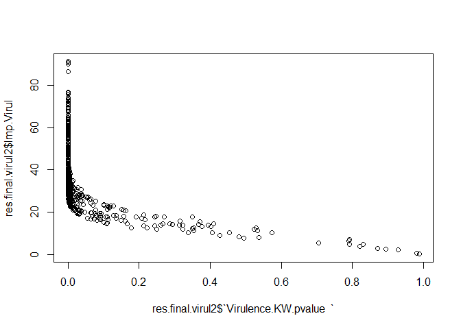

```r
plot(res.final.virul2$`Virulence.KW.pvalue  `, res.final.virul2$Imp.Virul)
```

Pas de surprise, les nombres d’ondes de faible p-value pour le test de Kruskall-Wallis ont de l’importance dans le modèle prédictif multivarié (importance KNN > 20%).

Les différences entre niveaux de virulence sont illustrées sur la sélection des 17 nombres d’onde les plus importants :

```r
nb.sel.virul <- rownames(res.final.virul2[res.final.virul2$Imp.Virul > 70, ])
nb.sel.virul
```

```
##  [1] "X1266" "X1265" "X1264" "X1263" "X1104" "X1103" "X1052" "X1051" "X1050"
## [10] "X1049" "X1048" "X969"  "X968"  "X933"  "X932"  "X931"  "X930"
```

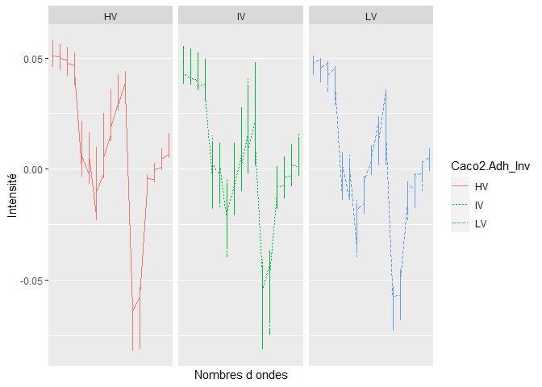

```r
Data.sel.virul     <- Data[, c(3, which(colnames(Data) %in% nb.sel.virul))]
Data.sel.col.virul <- melt(Data.sel.virul, id = c('Caco2.Adh_Inv'))
ggplot(Data.sel.col.virul, aes(x = variable, y = value)) + geom_line(aes(group = Caco2.Adh_Inv, color = Caco2.Adh_Inv, linetype = Caco2.Adh_Inv)) + xlab('Nombres d ondes') + ylab("Intensité") + scale_x_discrete(labels = NULL, breaks = NULL) + facet_wrap(~ Caco2.Adh_Inv)
```

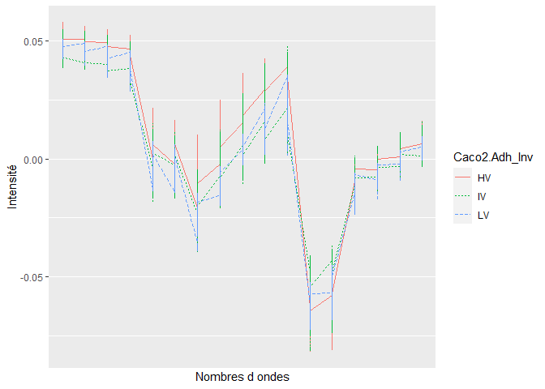

```r
ggplot(Data.sel.col.virul, aes(x = variable, y = value)) + geom_line(aes(group = Caco2.Adh_Inv, color = Caco2.Adh_Inv, linetype = Caco2.Adh_Inv)) + xlab('Nombres d ondes') + ylab("Intensité") + scale_x_discrete(labels = NULL, breaks = NULL)
```

## 9.2 Pour le pouvoir colonisateur

```r
res.final.coloni0 <- as.data.frame(res.univar3[, 5:9])
res.final.coloni1 <- cbind.data.frame(res.cluster, res.final.coloni0)   # check mm ordre row.names
res.final.coloni2 <- cbind.data.frame(res.final.coloni1, Varimp.coloni[5, drop = F])
kable(head(res.final.coloni2))
```

|  | res.cluster | Colonisation.KW.pvalue | HC | HIC | LC | LIC | Imp.Coloni |
| --- | --- | --- | --- | --- | --- | --- | --- |
| X1300 | 2 | 0.0433137 | b | ab | a | ab | 23.96691 |
| X1299 | 2 | 0.0496284 | a | a | a | a | 22.18080 |
| X1298 | 2 | 0.0668016 | a | a | a | a | 21.31275 |
| X1297 | 2 | 0.0641881 | ab | b | a | ab | 21.16310 |
| X1296 | 2 | 0.0517799 | ab | b | a | ab | 22.07959 |
| X1295 | 2 | 0.0212466 | ab | b | a | ab | 24.98609 |

```r
write.xlsx(res.final.coloni2, file = "Res_Salmo_Model_Colonisation.xlsx", append = FALSE)
```

Comparaison des importances univariées (Colonisation.KW.pvalue) et multivariées (Imp.Coloni) où les nombres d’ondes peuvent interagir entre eux :

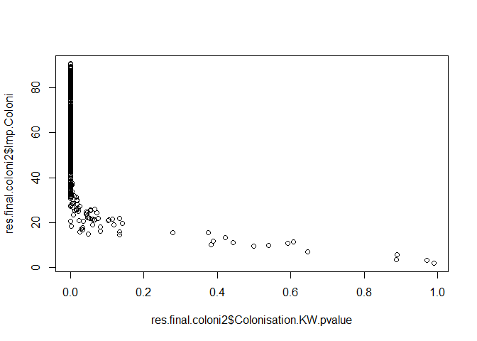

```r
plot(res.final.coloni2$"Colonisation.KW.pvalue", res.final.coloni2$Imp.Coloni)
```

Pas de surprise, les nombres d’ondes de faible p-value pour le test de Kruskall-Wallis ont de l’importance dans le modèle prédictif multivarié (importance KNN > 20%).

Les différences entre niveaux de pouvoir colonisateur sont illustrées sur la sélection des 136 nombres d’onde les plus importants :

```r
nb.sel.coloni <- rownames(res.final.coloni2[res.final.coloni2$Imp.Coloni > 70, ])
nb.sel.coloni
```

```
##   [1] "X1274" "X1273" "X1272" "X1271" "X1270" "X1269" "X1248" "X1247" "X1246"
##  [10] "X1245" "X1244" "X1243" "X1242" "X1241" "X1240" "X1239" "X1238" "X1222"
##  [19] "X1221" "X1220" "X1219" "X1218" "X1217" "X1201" "X1200" "X1199" "X1198"
##  [28] "X1197" "X1196" "X1195" "X1194" "X1177" "X1176" "X1172" "X1171" "X1170"
##  [37] "X1157" "X1156" "X1155" "X1154" "X1153" "X1152" "X1151" "X1150" "X1149"
##  [46] "X1148" "X1147" "X1146" "X1145" "X1144" "X1143" "X1142" "X1141" "X1140"
##  [55] "X1107" "X1106" "X1105" "X1104" "X1095" "X1094" "X1093" "X1092" "X1091"
##  [64] "X1090" "X1089" "X1088" "X1087" "X1086" "X1082" "X1081" "X1080" "X1079"
##  [73] "X1078" "X1077" "X1076" "X1075" "X1070" "X1069" "X1068" "X1067" "X1066"
##  [82] "X1065" "X1064" "X1063" "X1062" "X1061" "X1060" "X1056" "X1055" "X1054"
##  [91] "X1053" "X1052" "X1051" "X1043" "X1042" "X1041" "X1040" "X1039" "X1038"
## [100] "X1032" "X1031" "X1030" "X1029" "X1028" "X1027" "X1026" "X1025" "X1024"
## [109] "X1023" "X1022" "X1021" "X1020" "X1019" "X1018" "X999"  "X998"  "X997"
## [118] "X973"  "X972"  "X971"  "X970"  "X969"  "X968"  "X967"  "X938"  "X930"
## [127] "X929"  "X928"  "X918"  "X917"  "X916"  "X915"  "X914"  "X884"  "X883"
## [136] "X882"
```

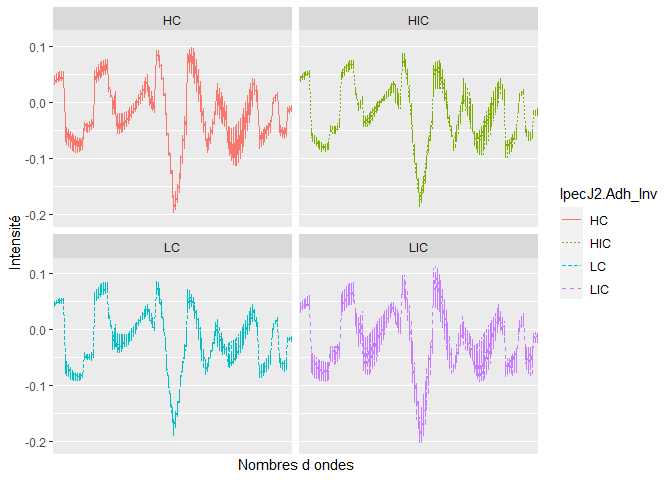

```r
Data.sel.coloni     <- Data[, c(4, which(colnames(Data) %in% nb.sel.coloni))]
Data.sel.col.coloni <- melt(Data.sel.coloni, id = c('IpecJ2.Adh_Inv'))
ggplot(Data.sel.col.coloni, aes(x = variable, y = value)) + geom_line(aes(group = IpecJ2.Adh_Inv, color = IpecJ2.Adh_Inv, linetype = IpecJ2.Adh_Inv)) + xlab('Nombres d ondes') + ylab("Intensité") + scale_x_discrete(labels = NULL, breaks = NULL) + facet_wrap(~ IpecJ2.Adh_Inv)
```

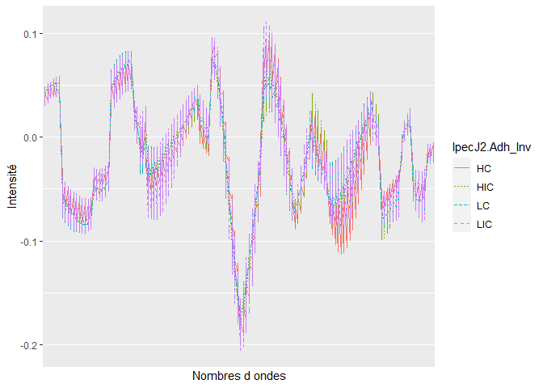

```r
ggplot(Data.sel.col.coloni, aes(x = variable, y = value)) + geom_line(aes(group = IpecJ2.Adh_Inv, color = IpecJ2.Adh_Inv, linetype = IpecJ2.Adh_Inv)) + xlab('Nombres d ondes') + ylab("Intensité") + scale_x_discrete(labels = NULL, breaks = NULL)
```

# 10 Bilan

Le modèle qui prédit au mieux les **niveaux de virulence** est la classification des K plus proches voisins, avec les performances suivantes :

Associés à ce modèle multivarié, 17 nombres d’ondes différencient très significativement les trois niveaux de virulence

Le modèle qui prédit au mieux les niveaux de **pouvoir colonisateur** est la classification des K plus proches voisins, avec les performances suivantes :

Associés à ce modèle multivarié, 136 nombres d’ondes différencient très significativement les quatre niveaux de pouvoir colonisateur.